# ENSEMBLE METHODS

### Data and Web Mining Project 2023/2024

#### 876928 Minto Gian Marco - 877148 Conte Alessandro

## What are the ensemble methods?

Ensemble methods are machine learning techniques that combine the predictions of multiple individual models to improve overall performance and generalization. These methods are based on the idea that combining multiple models can often yield better results than using individual models alone. Ensemble methods are particularly effective when applied to diverse and independent models.

## What are the advantages of using them?

**Ensemble methods in machine learning provide several benefits.**  
They are known for significantly improving model performance by combining predictions from multiple models.  
Some key advantages include **enhanced accuracy**, **robustness**, and a **reduced risk of overfitting or underfitting**.  
Ensembles are **versatile**, **adaptable** to various algorithms and tasks, and **effective** in handling nonlinear relationships within data. Despite their power, implementing ensemble methods is **straightforward**, often supported by libraries. They offer interpretability through insights into feature importance, making them valuable in diverse domains such as finance, cybersecurity, healthcare and natural language processing.

## What are the cons of using them?

**Ensemble methods in machine learning have notable drawbacks to consider.**  
Firstly, they come with **increased computational complexity** and **longer training times** due to the need to combine multiple models. The interpretability of ensembles, especially those with different models, can be challenging. Despite their ability to reduce overfitting, there are cases where ensembles **may perform poorly on test sets**.  
Practical concerns include **increased storage requirements**, **sensitivity to noisy data**, and the **necessity for careful implementation and optimization**.  
The success of ensembles depends on the diversity among individual models; lack of diversity can make their performance worse. While ensembles often improve accuracy, there's no guarantee of improvement, and in some instances, a well-tuned single model may be equally effective.

## Bagging and Boosting

**Bagging (Bootstrap Aggregating):** Bagging involves training **multiple instances** of the same learning algorithm on **different subsets** of the training data, achieved through bootstrap sampling (random sampling with replacement). Each model in the ensemble is **trained independently**, resulting in different models. The predictions of individual models are aggregated through techniques such as averaging (for regression) or voting (for classification). A well-known example is Random Forest, which employs decision trees as base models (topic not implemented in this project).

**Boosting:** Boosting is an iterative ensemble method that focuses on **improving the weaknesses of individual models**. It employs **sequential learning**, where models are trained one after the other. Each subsequent model assigns different weights to training instances, giving more weight to misclassified instances from the previous models. Boosting is adaptive, with each model aiming to correct errors made by its predecessors, resulting in a strong learner. The algorithm adopted in this project is AdaBoost.

**Key Differences:**

- **Training Process:** Bagging trains models independently, while boosting trains models sequentially, with each model adjusting based on the performance of the previous ones.
- **Weighting of Instances:** Bagging assigns equal weights to all instances, whereas boosting assigns higher weights to misclassified instances, making them more influential in subsequent models.
- **Diversity:** Bagging aims for diversity by creating different subsets of the data, while boosting builds a sequence of models that progressively correct errors, focusing on difficult instances.
- **Final Prediction:** In bagging, the final prediction is often an average or majority vote. In boosting, the final prediction is a weighted combination of the individual models.

## Base classifier - Decision Tree

We decided to use **decision trees as base classifiers** to demonstrate the functioning of Bagging and Boosting is advantageous for several reasons.  
Decision trees are **robust to noise**, making them suitable for Bagging, where multiple trees are trained on random subsets of the dataset.  
Their **high variance** is addressed in Bagging by aggregating predictions from multiple independent trees, reducing overall variance and improving generalization.  
Additionally, the **adaptability** of decision trees makes them effective in Boosting, where subsequent trees focus on instances misclassified by previous models.  
The ease of **parallelization** during decision tree training enhances efficiency in Bagging and Boosting.  
Lastly, the **interpretability** of decision trees gets easier the understanding and visualization, making them a good choice for illustrating ensemble algorithms like Bagging and Boosting.

## Aim of the project

Our goal is to implement and understand **how the ensemble methods works** by applying the related algorithms on two datasets and comparing the results in term of accuracy, bias and variance.

## The datasets

Our choice was to use **two datasets**, in one of which the data structures were created by tuning the hyper-parameters, so that we had two models customized to demonstrate Bagging and Boosting.

The first one is called **"Online Shoppers Purchasing Intention"** and consists of a **real-time online shopper behavior analysis system** consisting of classify a user who enters the website and makes a purchase within it (website name not public). The target variable, "Revenue", is a boolean variable that takes value 'TRUE' if the customer makes a purchase, 'FALSE' otherwise.  
The dataset consists of **17 features** and one target variable (10 numerical and 8 categorical attributes) and it has **12330 instances**.

The second dataset is called **"Predict students' dropout and academic success"** and is created from a higher education institution (acquired from several disjoint databases) related to **students enrolled in different undergraduate degrees**, such as agronomy, design, education, nursing, journalism, management, social service, and technologies.  
The dataset includes information known at the time of student enrollment (academic path, demographics, and social-economic factors) and the students' academic performance at the end of the first and second semesters.  
The data is used to build classification models to predict **students' dropout and academic sucess**. The problem is formulated as a three category classification task.  
This dataset consist of **36 features** and one target variable and it has 4424 instances.  
The target variable is named 'Target' and it is a categorical variable that can assume 3 values: 'Dropout', 'Enrolled' and 'Graduate'.

# Dataset 1: Online Shoppers Purchasing Intention

## Dataset creation

Import the pandas library, read a CSV file into a DataFrame, and then view the first five rows of the DataFrame.

```python
import pandas as pd

df = pd.read_csv("C:/Users/aless/DWM_Jupyter_notebook/Dataset/online_shoppers_intention.csv")
df.head()
```

|  | Administrative | Administrative_Duration | Informational | Informational_Duration | ProductRelated | ProductRelated_Duration | BounceRates | ExitRates | PageValues | SpecialDay | Month | OperatingSystems | Browser | Region | TrafficType | VisitorType | Weekend | Revenue |
| --- | --- | --- | --- | --- | --- | --- | --- | --- | --- | --- | --- | --- | --- | --- | --- | --- | --- | --- |
| 0 | 0 | 0.0 | 0 | 0.0 | 1 | 0.000000 | 0.20 | 0.20 | 0.0 | 0.0 | Feb | 1 | 1 | 1 | 1 | Returning_Visitor | False | False |
| 1 | 0 | 0.0 | 0 | 0.0 | 2 | 64.000000 | 0.00 | 0.10 | 0.0 | 0.0 | Feb | 2 | 2 | 1 | 2 | Returning_Visitor | False | False |
| 2 | 0 | 0.0 | 0 | 0.0 | 1 | 0.000000 | 0.20 | 0.20 | 0.0 | 0.0 | Feb | 4 | 1 | 9 | 3 | Returning_Visitor | False | False |
| 3 | 0 | 0.0 | 0 | 0.0 | 2 | 2.666667 | 0.05 | 0.14 | 0.0 | 0.0 | Feb | 3 | 2 | 2 | 4 | Returning_Visitor | False | False |
| 4 | 0 | 0.0 | 0 | 0.0 | 10 | 627.500000 | 0.02 | 0.05 | 0.0 | 0.0 | Feb | 3 | 3 | 1 | 4 | Returning_Visitor | True | False |

## Missing values check

Checks for null values in the dataset, useful operation for data cleaning.

```python
df.isnull().sum()
```

[output not shown]

## Features mapping

Map the variable "month" in "n_Month" (since it is a categorical variable) by assigning an integer value from 1 to 10 to each month.  
Note that this dataset does not include the months of January and April

```python
df['Month'] = df['Month'].str.capitalize()  # prima lettera maiuscola parole (cancella (?))

mese_mapping = {
    'Feb': 1,
    'Mar': 2,
    'May': 3,
    'June': 4,
    'Jul': 5,
    'Aug': 6,
    'Sep': 7,
    'Oct': 8,
    'Nov': 9,
    'Dec': 10
}

df['n_Month'] = df['Month'].map(mese_mapping)

# Delete the Month column
df = df.drop(columns=['Month'])
```

Map the variable "VisitorType" in "TypeOfVisitor" (since it is a categorical variable) by assigning an integer value from 1 to 3 to each category.

```python
df['VisitorType'] = df['VisitorType'].str.capitalize() #anche qui come prima

visitator_mapping = {
    'Returning_visitor': 1,
    'New_visitor': 2,
    'Other': 3
}

df['TypeOfVisitor'] = df['VisitorType'].map(visitator_mapping)

# Delete the VisitorType column
df = df.drop(columns=['VisitorType'])
```

## Dataset split

Split the dataset into **train** (80% of the dataset) and **test** (20% of the dataset) sets.

```python
from sklearn.model_selection import train_test_split

# Dataset without target variable
X = df.drop("Revenue",axis='columns')
# Target variable
y = df.Revenue

X_train, X_test, y_train, y_test = train_test_split(X, y, test_size=0.2, random_state=42)
```

## Decision Tree model

Create the decision tree model

```python
from sklearn.tree import DecisionTreeClassifier

dt_model = DecisionTreeClassifier(random_state=42)
dt_model.fit(X_train, y_train)
```

```
DecisionTreeClassifier(random_state=42)
```

Plot the decision tree

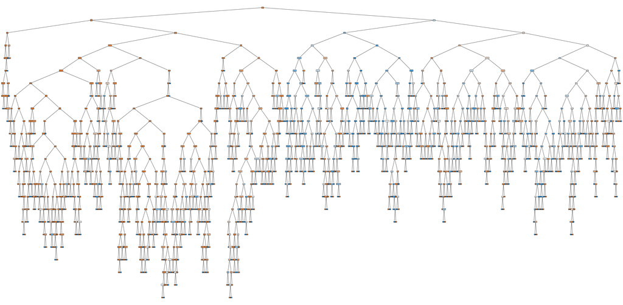

```python
from sklearn.tree import plot_tree
import matplotlib.pyplot as plt

plt.figure(figsize=(60, 30))
plot_tree(dt_model, feature_names=X.columns, class_names=['0', '1'], filled=True)
plt.show()
```

Evaluate the accuracy and depth of the decision tree

```python
from sklearn.metrics import accuracy_score

# Prevision
y_pred = dt_model.predict(X_test)

# Accuracy evaluation
accuracy = accuracy_score(y_test, y_pred)
print(f'Accuracy: {accuracy}')

# Depth evaluation
tree_variance = dt_model.get_depth()
print("Tree depth: {:.2f}".format(tree_variance))
```

```
Accuracy: 0.8588807785888077
Tree depth: 23.00
```

The **accuracy value** is approximately 0.86, suggesting that the model correctly predicted the target variable for around 86% of the samples in the test set. The **tree depth** value is 23, which represents the length of the longest path from the root node to a leaf node.

### Bias/Variance decomposition

```
Error/Bias/Variance at the last iteration: [0.11891727 0.07824716 0.04067011]
```

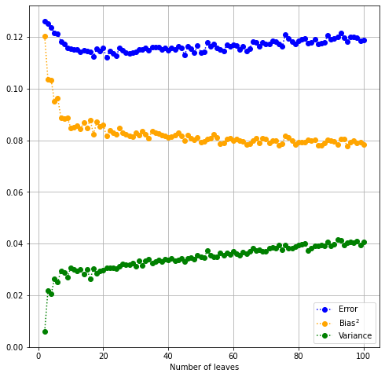

```python
from sklearn.utils import resample
from sklearn.tree import DecisionTreeClassifier
import numpy as np
import matplotlib.pyplot as plt
from sklearn.model_selection import train_test_split

N_TESTS = 20

stats = np.array([])

n_leaves = range(2, 101)

for l in n_leaves:
    y_preds = np.array([])

    for i in range(N_TESTS):
        Xs, ys = resample(X_train, y_train, n_samples=int(0.8 * len(y_train)))

        dt = DecisionTreeClassifier(max_leaf_nodes=l, random_state=42)
        dt.fit(Xs, ys)

        y_pred = dt.predict(X_test)
        y_preds = np.column_stack([y_preds, y_pred]) if y_preds.size else y_pred

    # Actual y vs. avg prediction
    dt_bias = np.mean((y_test.to_numpy().astype(float) - np.mean(y_preds, axis=1))**2)
    # Variance of predictions
    dt_variance = np.var(y_preds, axis=1)
    # MSE error
    dt_error = np.mean(((y_preds.astype(float) - y_test.to_numpy().reshape(-1, 1).astype(float))**2), axis=1)



    run_stats = np.array([dt_error.mean(), dt_bias.mean(), dt_variance.mean()])

    stats = np.column_stack([stats, run_stats]) if stats.size else run_stats

fig, ax = plt.subplots(figsize=(8, 8))

ax.plot(n_leaves, stats[0, :], 'o:', label='Error',  color='blue')
ax.plot(n_leaves, stats[1, :], 'o:', label='Bias$^2$',  color='orange')
ax.plot(n_leaves, stats[2, :], 'o:', label='Variance',  color='green')
ax.set_xlabel('Number of leaves')
ax.grid()
ax.legend()

# Extracting the final values of bias and variance
dt_final_bias = stats[1, -1]
dt_final_variance = stats[2, -1]

print("Error/Bias/Variance at the last iteration:", stats[:, -1])
```

As we can see from the graph, the **bias value tends to decrease** as the number of leaves increases while the **variance value tends to increase**.

The reason why this happens is that increasing the number of leaves can lead to a more complex model, that is able to fit the training data better. This can **reduce model bias**, as the model is able to **capture more intricate relationships** in the training data.  
However, increasing the complexity of the model can also lead to **greater variance**. A more complex model may overfit the specific details of the training data, making it more sensitive to variations in the data. This can lead to greater variance when the model is applied to new data.

The output values indicate that, at the end of the iteration process, the overall error of the model is about 0.12, the bias is about 0.08 and the variance is about 0.04.

It is important to note that the bias is greater than the variance. This may indicate that the model may be too simple to capture the complexity of the training data, which is reflected in a higher bias. However, the variance is relatively low, suggesting that the model is stable with respect to variations in the training data.

# Bagging Classifier

Implements a **BaggingClassifier** with a **Decision Tree base estimator**, trains it on our dataset, makes predictions, and evaluates its performance using accuracy as a metric.

```python
from sklearn.ensemble import BaggingClassifier
from sklearn.metrics import accuracy_score, precision_score, recall_score, f1_score
import numpy as np

bag_model = BaggingClassifier(estimator=dt_model, random_state=42)
bag_model.fit(X_train, y_train)

bag_pred = bag_model.predict(X_test)

bag_accuracy = accuracy_score(y_test, bag_pred)
print(f'Bagging classifier accuracy: {bag_accuracy}')
```

```
Bagging classifier accuracy: 0.8852392538523925
```

The value obtained means that the BaggingClassifier **correctly predicted** the target variable for about **88.5%** of the instances in the test dataset. In other words, the model achieved an accuracy of 88.5%, which indicates the percentage of correctly classified samples out of the total number of samples in the test set.

We used The BaggingClassifier from scikit-learn that implements the ensamble algorithm called "Bootstrap Aggregating" (or Bagging) to create a more robust and generalizable classifier. A brief explanation of the process is shown below:

**Bootstrap Sampling:**

Several training sets (subsets) are created by randomly selecting with replacement samples from the original training set. This process is known as bootstrap sampling.

**Training of Basic Classifiers:**

On each training subset, a base classifier is trained. In your case, the base classifier is a decision tree (DecisionTreeClassifier).

**Aggregation of Predictions:**

Once all base classifiers are trained, their predictions are combined to obtain a final prediction. In classification, a majority of the predictions (majority voting) are often used as the final prediction. The main goal of Bagging is to reduce the variance of the model, thus improving its generalization ability. By creating different training subsets and training different models on each, the likelihood of the model being too sensitive to particular features or noise in the training data is reduced.

### Bias/Variance analysis on Bagging Model

Conduct a **bias-variance tradeoff analysis** using the **Bagging classifier** created earlier with a Decision Tree baseline estimator. The code iteratively trains the classifier with a varying number of baseline estimators, runs multiple tests for each configuration, calculates the **bias**, **variance** and **error**, then plots the results. The code aims to visualize **how these metrics change** with the number of baseline estimators, providing insight into model performance.

```
Error/Bias/Variance at the last iteration: [0.11009732 0.08757908 0.02251825]
```

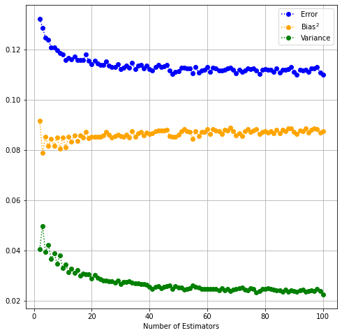

```python
from sklearn.ensemble import BaggingClassifier
from sklearn.tree import DecisionTreeClassifier
from sklearn.utils import resample
import numpy as np
import matplotlib.pyplot as plt
from sklearn.model_selection import train_test_split

SAMPLES = 20

stats = np.array([])

n_estimators = range(2, 101)

for n_est in n_estimators:
    y_preds = np.array([])

    for i in range(SAMPLES):
        Xs, ys = resample(X_train, y_train, n_samples=int(0.8 * len(y_train)))

        bag_model = BaggingClassifier(estimator=DecisionTreeClassifier(random_state=42), n_estimators=n_est, random_state=42)
        bag_model.fit(Xs, ys)

        y_pred = bag_model.predict(X_test)
        y_preds = np.column_stack([y_preds, y_pred]) if y_preds.size else y_pred

    # Actual y vs. avg prediction
    bag_bias = np.mean((y_test.to_numpy().astype(float) - np.mean(y_preds, axis=1))**2)
    # Variance of predictions
    bag_variance = np.var(y_preds, axis=1)
    # MSE error
    bag_error = np.mean(((y_preds.astype(float) - y_test.to_numpy().reshape(-1, 1).astype(float))**2), axis=1)


    run_stats = np.array([bag_error.mean(), bag_bias.mean(), bag_variance.mean()])

    stats = np.column_stack([stats, run_stats]) if stats.size else run_stats

fig, ax = plt.subplots(figsize=(8, 8))

ax.plot(n_estimators, stats[0, :], 'o:', label='Error',  color='blue')
ax.plot(n_estimators, stats[1, :], 'o:', label='Bias$^2$',  color='orange')
ax.plot(n_estimators, stats[2, :], 'o:', label='Variance',  color='green')
ax.set_xlabel('Number of Estimators')
ax.grid()
ax.legend()

# Extracting the final values of bias and variance
bag_final_bias = stats[1, -1]
bag_final_variance = stats[2, -1]

print("Error/Bias/Variance at the last iteration:", stats[:, -1])
```

## Decision Tree & Bagging Classifier with Cross-Validation

Evaluate the performance of our two machine learning models, a Decision Tree (dt_model) and a Bagging Classifier (bag_model), using cross-validation with different numbers of folds (cv=5, cv=10, cv=20, cv=50). The evaluation metrics considered are accuracy scores.

```python
from sklearn.model_selection import cross_val_score
from sklearn.metrics import accuracy_score, precision_score, recall_score, f1_score

# Decision Tree (dt_model)
tree_scores = cross_val_score(dt_model, X_train, y_train, cv=5, scoring='accuracy')
tree_scores1 = cross_val_score(dt_model, X_train, y_train, cv=10, scoring='accuracy')
tree_scores2 = cross_val_score(dt_model, X_train, y_train, cv=20, scoring='accuracy')
tree_scores3 = cross_val_score(dt_model, X_train, y_train, cv=50, scoring='accuracy')



# Bagging Classifier (bag_model)
bagging_scores = cross_val_score(bag_model, X_train, y_train, cv=5, scoring='accuracy')
bagging_scores1 = cross_val_score(bag_model, X_train, y_train, cv=10, scoring='accuracy')
bagging_scores2 = cross_val_score(bag_model, X_train, y_train, cv=20, scoring='accuracy')
bagging_scores3 = cross_val_score(bag_model, X_train, y_train, cv=50, scoring='accuracy')



print("Decision Tree - Accuracy with CV: {:.4f}".format(tree_scores.mean()))
print("Decision Tree - Accuracy with CV: {:.4f}".format(tree_scores1.mean()))
print("Decision Tree - Accuracy with CV: {:.4f}".format(tree_scores2.mean()))
print("Decision Tree - Accuracy with CV: {:.4f}".format(tree_scores3.mean()))

print("Bagging Classifier - Accuracy with CV: {:.4f}".format(bagging_scores.mean()))
print("Bagging Classifier - Accuracy with CV: {:.4f}".format(bagging_scores1.mean()))
print("Bagging Classifier - Accuracy with CV: {:.4f}".format(bagging_scores2.mean()))
print("Bagging Classifier - Accuracy with CV: {:.4f}".format(bagging_scores3.mean()))
```

```
Decision Tree - Accuracy with CV: 0.8606
Decision Tree - Accuracy with CV: 0.8599
Decision Tree - Accuracy with CV: 0.8600
Decision Tree - Accuracy with CV: 0.8611
Bagging Classifier - Accuracy with CV: 0.8811
Bagging Classifier - Accuracy with CV: 0.8813
Bagging Classifier - Accuracy with CV: 0.8798
Bagging Classifier - Accuracy with CV: 0.8821
```

We can see from the output that it is not always convenient to increase the number of folds (cv) to achieve better accuracy. One solution may be to automate the search for the optimal number of folds that returns the best accuracy, as we have done below.

## Automated detection for best cv

**Performs an extensive search for the optimal number of folds (cv) for cross-validation by iterating from 2 to 50.**

The code evaluates the Decision Tree (dt_model) and Bagging Classifier (bag_model) models for each value of cv and stores the mean accuracy scores along with the corresponding cv value in separate lists (tree_accuracies and bagging_accuracies).

After iterating through all values of cv, it identifies the **best accuracy** and its **associated cv value** for both the Decision Tree and Bagging Classifier models using the max function and lambda expressions. After that, it prints the results, indicating the best accuracy and the corresponding optimal cv value for each model.

```python
from sklearn.model_selection import cross_val_score
from sklearn.tree import DecisionTreeClassifier
from sklearn.ensemble import BaggingClassifier
import numpy as np

tree_accuracies = []
bagging_accuracies = []

for cv_value in range(2, 51):
    # Decision Tree
    tree_scores = cross_val_score(dt_model, X_train, y_train, cv=cv_value, scoring='accuracy')
    tree_accuracy = np.mean(tree_scores)
    tree_accuracies.append((tree_accuracy, cv_value))

    # Bagging Classifier
    bagging_scores = cross_val_score(bag_model, X_train, y_train, cv=cv_value, scoring='accuracy')
    bagging_accuracy = np.mean(bagging_scores)
    bagging_accuracies.append((bagging_accuracy, cv_value))

# best accuracy and cv value for Decision Tree
best_tree_accuracy, best_tree_cv = max(tree_accuracies, key=lambda x: x[0])

# best accuracy and cv value for Bagging Classifier
best_bagging_accuracy, best_bagging_cv = max(bagging_accuracies, key=lambda x: x[0])

print("Best Decision Tree Accuracy: {:.4f} with CV = {}".format(best_tree_accuracy, best_tree_cv))
print("Best Bagging Classifier Accuracy: {:.4f} with CV = {}".format(best_bagging_accuracy, best_bagging_cv))
```

```
Best Decision Tree Accuracy: 0.8653 with CV = 28
Best Bagging Classifier Accuracy: 0.8861 with CV = 37
```

# Boosting Classifier

Implement a **BoostingClassifier** with a **Decision Tree base estimator**, train it on our dataset, make predictions, and evaluate its performance using accuracy as a metric.

```python
from sklearn.model_selection import train_test_split
from sklearn.ensemble import AdaBoostClassifier
from sklearn.metrics import accuracy_score

adaboost_classifier = AdaBoostClassifier(dt_model, random_state=42)
adaboost_classifier.fit(X_train, y_train)
y_pred_adaboost = adaboost_classifier.predict(X_test)

accuracy_adaboost = accuracy_score(y_test, y_pred_adaboost)
print(f'Accuracy of AdaBoost model on test set: {accuracy_adaboost}')
```

[output not shown]

We used **scikit-learn's AdaBoostClassifier classifier** that uses the boosting algorithm called "AdaBoost" (Adaptive Boosting) to **create a strong classifier by combining several weak classifiers**. A brief explanation of the process is shown below:

**Training a Weak Classifier:**

Initially, a weak classifier is trained on the training set.

**Assigning Weights to Samples:**

An initial weight is assigned to each sample in the training set. Samples misclassified by the weak classifier receive higher weights.

**AdaBoost Iterations:**

AdaBoost iterates to construct a sequence of weak classifiers. At each iteration, a new weak classifier is trained, and sample weights are updated based on performance: they are incremented for misclassified samples and decremented for correctly classified samples.

**Construction of the Final Classifier:**

The final prediction is obtained by summing the weighted predictions of the individual weak classifiers. The classifiers that perform better influence the final prediction the most.

This process is repeated for a fixed number of iterations or until the performance of the model reaches a certain desired level.

## Bias/Variance analysis on Boosting Model

```
Error/Bias/Variance at the last iteration: [0.12084347 0.08427413 0.03656934]
```

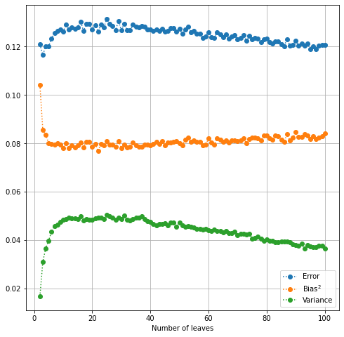

```python
from sklearn.utils import resample
from sklearn.tree import DecisionTreeClassifier
import numpy as np
import matplotlib.pyplot as plt
from sklearn.model_selection import train_test_split

SAMPLES = 20

stats = np.array([])

n_leaves = range(2, 101)

for l in n_leaves:
    y_preds = np.array([])

    for i in range(SAMPLES):
        Xs, ys = resample(X_train, y_train, n_samples=int(0.8 * len(y_train)))

        dt = AdaBoostClassifier(estimator=DecisionTreeClassifier(max_leaf_nodes=l, random_state=42), random_state=42)
        dt.fit(Xs, ys)

        y_pred = dt.predict(X_test)
        y_preds = np.column_stack([y_preds, y_pred]) if y_preds.size else y_pred

    # Actual y vs. avg prediction
    boost_bias = np.mean((y_test.to_numpy().astype(float) - np.mean(y_preds, axis=1))**2)

    # Variance of predictions
    boost_variance = np.var(y_preds, axis=1)
    # MSE error
    boost_error = np.mean(((y_preds.astype(float) - y_test.to_numpy().reshape(-1, 1).astype(float))**2), axis=1)


    run_stats = np.array([boost_error.mean(), boost_bias.mean(), boost_variance.mean()])

    stats = np.column_stack([stats, run_stats]) if stats.size else run_stats

fig, ax = plt.subplots(figsize=(8, 8))

ax.plot(n_leaves, stats[0, :], 'o:', label='Error')
ax.plot(n_leaves, stats[1, :], 'o:', label='Bias$^2$')
ax.plot(n_leaves, stats[2, :], 'o:', label='Variance')
ax.set_xlabel('Number of leaves')
ax.grid()
ax.legend()

# Extracting the final values of bias and variance
boost_final_bias = stats[1, -1]
boost_final_variance = stats[2, -1]

print("Error/Bias/Variance at the last iteration:", stats[:, -1])
```

## Decision Tree & Boosting Classifier with Cross-Validation

**Performs an extensive search for the optimal number of folds (cv) for cross-validation by iterating from 2 to 50.**

The code evaluates Boosting Classifier (adaboost_classifier) model for each value of cv and stores the mean accuracy scores along with the corresponding cv value in a list (boosting_accuracies).

```python
from sklearn.model_selection import cross_val_score
from sklearn.tree import DecisionTreeClassifier
from sklearn.ensemble import BaggingClassifier
import numpy as np

boosting_accuracies = []

for cv_value in range(2, 51):
    boosting_scores = cross_val_score(adaboost_classifier, X_train, y_train, cv=cv_value, scoring='accuracy')
    boosting_accuracy = np.mean(boosting_scores)
    boosting_accuracies.append((boosting_accuracy, cv_value))

# Find the best accuracy and its corresponding cv value for Bagging Classifier
best_boosting_accuracy, best_boosting_cv = max(boosting_accuracies, key=lambda x: x[0])

print("Best Boosting Classifier Accuracy: {:.4f} with CV = {}".format(best_boosting_accuracy, best_boosting_cv))
```

```
Best Boosting Classifier Accuracy: 0.8659 with CV = 49
```

## Values recap

**DECISION TREE (BASE MODEL)**

Accuracy: 0.8589  
Best Decision Tree Accuracy: 0.8653 with CV = 28  
Error/Bias/Variance at the last iteration: [0.11891727 0.07824716 0.04067011]

**BAGGING**

Bagging classifier accuracy: 0.8852 Best Bagging Classifier Accuracy: 0.8861 with CV = 37  
Error/Bias/Variance at the last iteration: [0.11009732 0.08757908 0.02251825]

**BOOSTING**

Accuracy of AdaBoost model on validation set: 0.8568  
Best Boosting Classifier Accuracy: 0.8659 with CV = 49  
Error/Bias/Variance at the last iteration: [0.12084347 0.08427413 0.03656934]

# Dataset 2: Predict students' dropout and academic success

## Dataset creation

Import the pandas library, read a CSV file into a DataFrame, and then view the first five rows of the DataFrame.

```python
import pandas as pd

#df_2 = pd.read_csv("/home/gian/Scrivania/DWM_23-24/PROGETTO_DWM/students.csv", delimiter=";")
df_2 = pd.read_csv("C:/Users/aless/DWM_Jupyter_notebook/Dataset/students_data.csv", delimiter=';')
```

## Missing values check

Checks for null values in the dataset, useful operation for data cleaning.

```python
df_2.isnull().sum()
```

```
Marital status                                    0
Application mode                                  0
Application order                                 0
Course                                            0
Daytime/evening attendance\t                      0
Previous qualification                            0
Previous qualification (grade)                    0
Nacionality                                       0
Mother's qualification                            0
Father's qualification                            0
Mother's occupation                               0
Father's occupation                               0
Admission grade                                   0
Displaced                                         0
Educational special needs                         0
Debtor                                            0
Tuition fees up to date                           0
Gender                                            0
Scholarship holder                                0
Age at enrollment                                 0
International                                     0
Curricular units 1st sem (credited)               0
Curricular units 1st sem (enrolled)               0
Curricular units 1st sem (evaluations)            0
Curricular units 1st sem (approved)               0
Curricular units 1st sem (grade)                  0
Curricular units 1st sem (without evaluations)    0
Curricular units 2nd sem (credited)               0
Curricular units 2nd sem (enrolled)               0
Curricular units 2nd sem (evaluations)            0
Curricular units 2nd sem (approved)               0
Curricular units 2nd sem (grade)                  0
Curricular units 2nd sem (without evaluations)    0
Unemployment rate                                 0
Inflation rate                                    0
GDP                                               0
Target                                            0
dtype: int64
```

## Features mapping

Map the variable "Target" (since it is a categorical variable) by assigning an integer value from 1 to 3 to each category.

```python
df_2['Target'] = df_2['Target'].str.capitalize() # first letter capitalized

target_mapping = {
    'Dropout': 1,
    'Enrolled': 2,
    'Graduate': 3
}

df_2['Target'] = df_2['Target'].map(target_mapping)
```

## Dataset split

```python
from sklearn.model_selection import train_test_split

X = df_2.drop("Target", axis='columns')
y = df_2.Target

X_train, X_temp, y_train, y_temp = train_test_split(X, y, test_size=0.3, random_state=42)
X_val, X_test, y_val, y_test = train_test_split(X_temp, y_temp, test_size=0.67, random_state=42)
```

## Decision tree models

Create a **decision tree** and two classifiers based on it, a **bagging classifier** and a **boosting classifier**

```python
from sklearn.tree import DecisionTreeClassifier
from sklearn.ensemble import BaggingClassifier
from sklearn.ensemble import AdaBoostClassifier

# Decision Tree
dt_model = DecisionTreeClassifier(random_state=42)
dt_model.fit(X_train, y_train)

# Bagging
bag_model = BaggingClassifier(dt_model, random_state=42)
bag_model.fit(X_train, y_train)

# Boosting
boos_model = AdaBoostClassifier(dt_model, random_state=42)
boos_model.fit(X_train, y_train)
```

```
AdaBoostClassifier(estimator=DecisionTreeClassifier(random_state=42),
                   random_state=42)
```

## Tree plot

Plot the decision tree

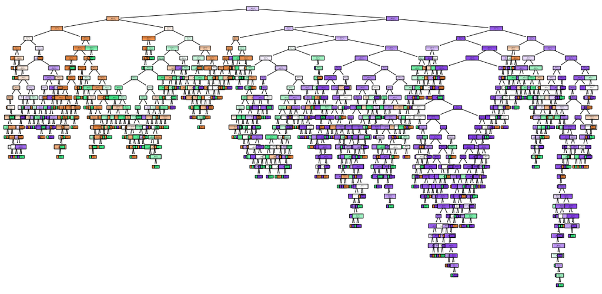

```python
from sklearn.tree import plot_tree
import matplotlib.pyplot as plt
import numpy as np

unique_classes = np.unique(y)

plt.figure(figsize=(20, 10))
plot_tree(dt_model, feature_names=X.columns, class_names=[str(i) for i in unique_classes], filled=True, rounded=True)
plt.show()
```

## Train and test for bagging and boosting on validation set

Make predictions about each model and calculate the **accuracy**, **mean square error** (MSE), **bias** and **variance** of each model using the bias-variance decomposition. The objective is to compare the performance of the three models based on these metrics.

```python
from IPython.display import display, HTML

X_train_np = X_train.values if isinstance(X_train, pd.DataFrame) else X_train
y_train_np = y_train.values if isinstance(y_train, pd.Series) else y_train
X_val_np = X_val.values if isinstance(X_val, pd.DataFrame) else X_val
y_val_np = y_val.values if isinstance(y_val, pd.Series) else y_val
X_test_np = X_test.values if isinstance(X_test, pd.DataFrame) else X_test
y_test_np = y_test.values if isinstance(y_test, pd.Series) else y_test

# The conversion lost the column names
# Add column names to X_test_np to solve the warning problems
X_val_np_with_columns = X_val.copy()  # insert a copy of X_test into the variable
X_val_np_with_columns.columns = X_train.columns # rename columns taking the names from X_train

# Use the feature names during prediction
X_val_np_with_columns = X_val_np_with_columns.values


y_val_pred = dt_model.predict(X_val_np_with_columns)
accuracy = accuracy_score(y_val, y_val_pred)

mse, bias, var = bias_variance_decomp(dt_model, X_train_np, y_train_np, X_val_np, y_val_np, loss='mse', random_seed=42)
display(HTML("<strong>B/V Dec Decision Tree model</strong>"))
print("Accuracy: {:.6f}".format(accuracy))
print("Mean Squared Error: {:.6f}".format(mse))
print("Bias^2: {:.6f}".format(bias))
print("Varianza: {:.6f}".format(var))


y_val_pred = bag_model.predict(X_val_np_with_columns)
accuracy = accuracy_score(y_val, y_val_pred)

mse, bias, var = bias_variance_decomp(bag_model, X_train_np, y_train_np, X_val_np, y_val_np, loss='mse', random_seed=42)
display(HTML("<strong>B/V Dec Bagging model</strong>"))
print("Accuracy: {:.6f}".format(accuracy))
print("Mean Squared Error: {:.6f}".format(mse))
print("Bias^2: {:.6f}".format(bias))
print("Varianza: {:.6f}".format(var))


y_val_pred = boos_model.predict(X_val_np_with_columns)
accuracy = accuracy_score(y_val, y_val_pred)

mse, bias, var = bias_variance_decomp(boos_model, X_train_np, y_train_np, X_val_np, y_val_np, loss='mse', random_seed=42)
display(HTML("<strong>B/V Dec Boosting model</strong>"))
print("Accuracy: {:.6f}".format(accuracy))
print("Mean Squared Error: {:.6f}".format(mse))
print("Bias^2: {:.6f}".format(bias))
print("Varianza: {:.6f}".format(var))
```

**B/V Dec Decision Tree model**

```
Accuracy: 0.659817
Mean Squared Error: 0.645046
Bias^2: 0.352089
Varianza: 0.292956
```

**B/V Dec Bagging model**

```
Accuracy: 0.714612
Mean Squared Error: 0.543699
Bias^2: 0.384679
Varianza: 0.159020
```

**B/V Dec Boosting model**

```
Accuracy: 0.650685
Mean Squared Error: 0.645605
Bias^2: 0.353099
Varianza: 0.292506
```

## Bagging - hyper-parameters tuning

Conduct **performance evaluation** of the **Bagging Classifier**, using **Grid Search Cross Validation** to select the best hyperparameters. Then calculate and compare the accuracy, mean square error (MSE), bias, and variance metrics with those of the decision tree created before.

A Bagging Classifier is created using the Decision Tree as the baseline estimator. Grid Search Cross Validation is used to search for the best hyperparameters for the Bagging Classifier, specifically the number of estimators, the maximum depth of the baseline estimators, and the maximum sample fraction to be used for each estimator.

After the hyperparameters are searched, the best parameters for the Bagging Classifier are printed. The optimized Bagging model is then evaluated on the validation set, and metrics of accuracy, MSE, bias and variance are calculated. These metrics are compared with those of the unoptimized Decision Tree.

```python
import numpy as np
from sklearn.model_selection import GridSearchCV
from sklearn.metrics import accuracy_score, mean_squared_error
from mlxtend.evaluate import bias_variance_decomp


X_train_np = X_train.values if isinstance(X_train, pd.DataFrame) else X_train
y_train_np = y_train.values if isinstance(y_train, pd.Series) else y_train
X_val_np = X_val.values if isinstance(X_val, pd.DataFrame) else X_val
y_val_np = y_val.values if isinstance(y_val, pd.Series) else y_val

# Decision Tree
y_val_pred = dt_model.predict(X_val_np_with_columns)
accuracy = accuracy_score(y_val, y_val_pred)

mse, bias, var = bias_variance_decomp(dt_model, X_train_np, y_train_np, X_val_np, y_val_np, loss='mse', random_seed=42)
display(HTML("<strong>B/V Dec Decision Tree model</strong>"))
print("Accuracy: {:.6f}".format(accuracy))
print("Mean Squared Error: {:.6f}".format(mse))
print("Bias^2: {:.6f}".format(bias))
print("Varianza: {:.6f}".format(var))

bagging_params = {
    'n_estimators': [10, 50, 100],
    'estimator__max_depth': [None, 5, 10, 15],
    'max_samples': [0.5, 0.7, 1.0]
}

bagging_grid_search = GridSearchCV(bag_model, bagging_params, cv=5)
bagging_grid_search.fit(X_train_np, y_train_np)

print("Best parameters for Bagging Classifier:", bagging_grid_search.best_params_)

# Compute the performance of the Bagging model.
bagging_best_model = bagging_grid_search.best_estimator_
bagging_pred = bagging_best_model.predict(X_val_np)
bagging_accuracy = accuracy_score(y_val_np, bagging_pred)

# Compute Bias and variance manually
y_pred_train = bagging_best_model.predict(X_val_np)
mse, bias, var = bias_variance_decomp(bagging_best_model, X_train_np, y_train_np, X_val_np, y_val_np, loss='mse', random_seed=42)
display(HTML("<strong>B/V Dec Bagging model</strong>"))
print("Accuracy: {:.6f}".format(bagging_accuracy))
print("Mean Squared Error: {:.6f}".format(mse))
print("Bias^2: {:.6f}".format(bias))
print("Varianza: {:.6f}".format(var))
```

**B/V Dec Decision Tree model**

```
Accuracy: 0.659817
Mean Squared Error: 0.645046
Bias^2: 0.352089
Varianza: 0.292956
Best parameters for Bagging Classifier: {'estimator__max_depth': 15, 'max_samples': 1.0, 'n_estimators': 50}
```

**B/V Dec Bagging model**

```
Accuracy: 0.730594
Mean Squared Error: 0.532432
Bias^2: 0.421828
Varianza: 0.110603
```

Looking at the result obtained, we can say that the Bagging Classifier shows a significant improvement over the basic Decision Tree. The reduction in variance indicates that the ensemble helped make the model more robust by reducing the sensitivity to fluctuations in the data and generalizing better.

## Bagging - test on test set

Repeat the same steps performed above on the test set part.

```python
# The conversion lost the column names
# Add column names to X_test_np to solve the warning problems
X_test_np_with_columns = X_test.copy()  # insert a copy of X_test into the variable
X_test_np_with_columns.columns = X_train.columns # rename columns taking the names from X_train

X_test_np_with_columns = X_test_np_with_columns.values

# Decision Tree
y_test_pred = dt_model.predict(X_test_np_with_columns)
accuracy = accuracy_score(y_test, y_test_pred)

mse, bias, var = bias_variance_decomp(dt_model, X_train_np, y_train_np, X_test_np, y_test_np, loss='mse', random_seed=42)
display(HTML("<strong>B/V Dec Decision Tree model</strong>"))
print("Accuracy: {:.6f}".format(accuracy))
print("Mean Squared Error: {:.6f}".format(mse))
print("Bias^2: {:.6f}".format(bias))
print("Varianza: {:.6f}".format(var))


bagging_params = {
    'n_estimators': [10, 50, 100],
    'estimator__max_depth': [None, 5, 10, 15],
    'max_samples': [0.5, 0.7, 1.0]
}

bagging_grid_search = GridSearchCV(bag_model, bagging_params, cv=5)
bagging_grid_search.fit(X_test_np, y_test_np)

print("Best parameters for Bagging Classifier:", bagging_grid_search.best_params_)

# Compute the performance of the Bagging model.
bagging_best_model = bagging_grid_search.best_estimator_
bagging_pred = bagging_best_model.predict(X_test_np)
bagging_accuracy = accuracy_score(y_test_np, bagging_pred)

# Compute Bias and variance manually
y_pred_train = bagging_best_model.predict(X_test_np)
mse, bias, var = bias_variance_decomp(bagging_best_model, X_train_np, y_train_np, X_test_np, y_test_np, loss='mse', random_seed=42)
display(HTML("<strong>B/V Dec Bagging model</strong>"))
print("Accuracy: {:.6f}".format(bagging_accuracy))
print("Mean Squared Error: {:.6f}".format(mse))
print("Bias^2: {:.6f}".format(bias))
print("Varianza: {:.6f}".format(var))
```

**B/V Dec Decision Tree model**

```
Accuracy: 0.692135
Mean Squared Error: 0.579421
Bias^2: 0.292566
Varianza: 0.286855
Best parameters for Bagging Classifier: {'estimator__max_depth': 5, 'max_samples': 0.5, 'n_estimators': 100}
```

**B/V Dec Bagging model**

```
Accuracy: 0.829213
Mean Squared Error: 0.451657
Bias^2: 0.390877
Varianza: 0.060780
```

## Boosting - hyper-parameters tuning

Perform a procedure similar to the previous one, but focusing on the **AdaBoost Classifier** instead of the Bagging Classifier. Evaluate the performance of the **AdaBoost model** after using **Grid Search Cross Validation** to select the best hyperparameters.

The first part of the code prints the accuracy, MSE, bias, and variance metrics for the Decision Tree **without hyperparameter optimization**, providing an initial reference for comparison. Next, the search parameters for the AdaBoost Classifier are defined, which includes the number of estimators and learning rate as key hyperparameters.

**Grid Search Cross Validation** is then used to find the best hyperparameters for the AdaBoost Classifier. Once the best parameters are identified, they are printed on the screen. This step is crucial because it allows the optimal combination of hyperparameters that maximizes model performance to be identified.

After the hyperparameter search step, the code uses the optimized AdaBoost model to make predictions about the validation set. Next, accuracy, MSE, bias, and variance metrics are calculated and printed, providing a complete view of the performance of the AdaBoost model compared to the baseline Decision Tree.

```python
# Decision Tree
y_val_pred = dt_model.predict(X_val_np_with_columns)
accuracy = accuracy_score(y_val, y_val_pred)

mse, bias, var = bias_variance_decomp(dt_model, X_train_np, y_train_np, X_val_np, y_val_np, loss='mse', random_seed=42)
display(HTML("<strong>B/V Dec Decision Tree model</strong>"))
print("Accuracy: {:.6f}".format(accuracy))
print("Mean Squared Error: {:.6f}".format(mse))
print("Bias^2: {:.6f}".format(bias))
print("Varianza: {:.6f}".format(var))


adaboost_params = {
    'n_estimators': [50, 100, 200],
    'learning_rate': [0.01, 0.02, 0.05, 0.1, 0.5, 1.0]
}

adaboost_grid_search = GridSearchCV(boos_model, adaboost_params, cv=5)
adaboost_grid_search.fit(X_train_np, y_train_np)
print("\nBest parameters for AdaBoost Classifier:", adaboost_grid_search.best_params_)

adaboost_best_model = adaboost_grid_search.best_estimator_
adaboost_pred = adaboost_best_model.predict(X_val_np)
adaboost_accuracy = accuracy_score(y_val_np, adaboost_pred)

y_pred_train_adaboost = adaboost_best_model.predict(X_val_np)

mse, bias, var = bias_variance_decomp(adaboost_best_model, X_train_np, y_train_np, X_val_np, y_val_np, loss='mse', random_seed=42)
display(HTML("<strong>B/V Dec Boosting model</strong>"))
print("Accuracy: {:.6f}".format(adaboost_accuracy))
print("Mean Squared Error: {:.6f}".format(mse))
print("Bias^2: {:.6f}".format(bias))
print("Varianza: {:.6f}".format(var))
```

**B/V Dec Decision Tree model**

```
Accuracy: 0.659817
Mean Squared Error: 0.645046
Bias^2: 0.352089
Varianza: 0.292956

Best parameters for AdaBoost Classifier: {'learning_rate': 0.01, 'n_estimators': 50}
```

**B/V Dec Boosting model**

```
Accuracy: 0.657534
Mean Squared Error: 0.645605
Bias^2: 0.353099
Varianza: 0.292506
```

## Boosting - Decision Tree hyper-parameters tuning

Create the tuned decision tree mentioned before

```python
# Decision Tree with high bias
dt_model_tunned = DecisionTreeClassifier(max_depth=2, random_state=42, min_samples_split=10,
                                        min_samples_leaf=5, max_features=None)
dt_model_tunned.fit(X_train, y_train)


boos_model_tunned = AdaBoostClassifier(dt_model_tunned, n_estimators=100, random_state=42, learning_rate=0.2)
boos_model_tunned.fit(X_train, y_train)


y_val_pred = dt_model_tunned.predict(X_val_np_with_columns)
accuracy = accuracy_score(y_val, y_val_pred)

mse, bias, var = bias_variance_decomp(dt_model_tunned, X_train_np, y_train_np, X_val_np, y_val_np, loss='mse', random_seed=42)
display(HTML("<strong>B/V Dec Decision Tree model</strong>"))
print("Accuracy: {:.6f}".format(accuracy))
print("Mean Squared Error: {:.6f}".format(mse))
print("Bias^2: {:.6f}".format(bias))
print("Varianza: {:.6f}".format(var))


y_val_pred = boos_model_tunned.predict(X_val_np_with_columns)
accuracy = accuracy_score(y_val, y_val_pred)

mse, bias, var = bias_variance_decomp(boos_model_tunned, X_train_np, y_train_np, X_val_np, y_val_np, loss='mse', random_seed=42)
display(HTML("<strong>B/V Dec Boosting model</strong>"))
print("Accuracy: {:.6f}".format(accuracy))
print("Mean Squared Error: {:.6f}".format(mse))
print("Bias^2: {:.6f}".format(bias))
print("Varianza: {:.6f}".format(var))
```

**B/V Dec Decision Tree model**

```
Accuracy: 0.671233
Mean Squared Error: 0.675000
Bias^2: 0.591075
Varianza: 0.083925
```

**B/V Dec Boosting model**

```
Accuracy: 0.735160
Mean Squared Error: 0.509669
Bias^2: 0.410734
Varianza: 0.098935
```

Looking at the obtained outputs we can deduce that by using a tree specially created to have high bias and low variance we are able to show that the AdaBoost algorithm is able to decrease the bias in a model. Following we will verify this directly on the test set

## Boosting - Training and test on Test set

Repeat the same steps performed above on the test set part.

```python
y_test_pred = dt_model_tunned.predict(X_test_np_with_columns)
accuracy = accuracy_score(y_test, y_test_pred)

mse, bias, var = bias_variance_decomp(dt_model_tunned, X_train_np, y_train_np, X_test_np, y_test_np, loss='mse', random_seed=42)
display(HTML("<strong>B/V Dec Decision Tree model</strong>"))
print("Accuracy: {:.6f}".format(accuracy))
print("Mean Squared Error: {:.6f}".format(mse))
print("Bias^2: {:.6f}".format(bias))
print("Varianza: {:.6f}".format(var))


y_test_pred = boos_model_tunned.predict(X_test_np_with_columns)
accuracy = accuracy_score(y_test, y_test_pred)

mse, bias, var = bias_variance_decomp(boos_model_tunned, X_train_np, y_train_np, X_test_np, y_test_np, loss='mse', random_seed=42)
display(HTML("<strong>B/V Dec Boosting model</strong>"))
print("Accuracy: {:.6f}".format(accuracy))
print("Mean Squared Error: {:.6f}".format(mse))
print("Bias^2: {:.6f}".format(bias))
print("Varianza: {:.6f}".format(var))
```

**B/V Dec Decision Tree model**

```
Accuracy: 0.724719
Mean Squared Error: 0.584433
Bias^2: 0.517290
Varianza: 0.067142
```

**B/V Dec Boosting model**

```
Accuracy: 0.760674
Mean Squared Error: 0.411989
Bias^2: 0.325242
Varianza: 0.086747
```

Looking at the obtained outputs, we can conclude that by using a tree specifically created to have **high bias** and low variance we are able to show that the **AdaBoost algorithm is able to decrease the bias in a model**

## Boosting - Tree plot with tuning

Plot the tunned decision tree

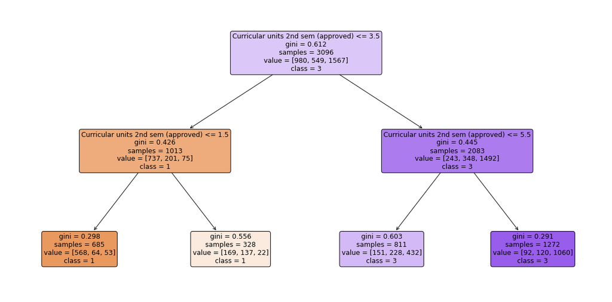

```python
from sklearn.tree import plot_tree
import matplotlib.pyplot as plt
import numpy as np
# Decision Tree with high bias
dt_model_tunned = DecisionTreeClassifier(max_depth=2, random_state=42, min_samples_split=10,
                                        min_samples_leaf=5, max_features=None)
dt_model_tunned.fit(X_train, y_train)

unique_classes = np.unique(y)

plt.figure(figsize=(20, 10))
plot_tree(dt_model_tunned, feature_names=X.columns, class_names=[str(i) for i in unique_classes], filled=True, rounded=True)
plt.show()
```

## Boosting - tuning with Cross-Validation

Conduct **performance evaluation** of the **Boosting Classifier**, using **Grid Search Cross Validation** to select the best hyperparameters. Then calculate and compare the accuracy, mean square error (MSE), bias, and variance metrics with those of the previous tuned decision tree.

A Boosting Classifier is created using the tuned Decision Tree as the baseline estimator. Grid Search Cross Validation is used to search for the best hyperparameters for the Boosting Classifier, specifically the number of estimators and the learning rate.

After the hyperparameters are searched, the best parameters for the Boosting Classifier are printed. The optimized Boosting model is then evaluated on the test set, and metrics of accuracy, MSE, bias and variance are calculated. These metrics are compared with those of the tuned Decision Tree.

```python
y_test_pred = dt_model_tunned.predict(X_test_np_with_columns)
accuracy = accuracy_score(y_test, y_test_pred)

mse, bias, var = bias_variance_decomp(dt_model_tunned, X_train_np, y_train_np, X_test_np, y_test_np, loss='mse', random_seed=42)
display(HTML("<strong>B/V Dec Decision Tree model</strong>"))
print("Accuracy: {:.6f}".format(accuracy))
print("Mean Squared Error: {:.6f}".format(mse))
print("Bias^2: {:.6f}".format(bias))
print("Varianza: {:.6f}".format(var))


adaboost_params = {
    'n_estimators': [50, 100, 200],
    'learning_rate': [0.01, 0.02, 0.05, 0.1, 0.5]
}

adaboost_grid_search = GridSearchCV(boos_model_tunned, adaboost_params, cv=5)
adaboost_grid_search.fit(X_train_np, y_train_np)
print("\nBest parameters for AdaBoost Classifier:", adaboost_grid_search.best_params_)

adaboost_best_model = adaboost_grid_search.best_estimator_
adaboost_pred = adaboost_best_model.predict(X_test_np)
adaboost_accuracy = accuracy_score(y_test_np, adaboost_pred)

y_pred_train_adaboost = adaboost_best_model.predict(X_test_np)

mse, bias, var = bias_variance_decomp(adaboost_best_model, X_train_np, y_train_np, X_test_np, y_test_np, loss='mse', random_seed=42)
display(HTML("<strong>B/V Dec Boosting model</strong>"))
print("Accuracy: {:.6f}".format(adaboost_accuracy))
print("Mean Squared Error: {:.6f}".format(mse))
print("Bias^2: {:.6f}".format(bias))
print("Varianza: {:.6f}".format(var))
```

**B/V Dec Decision Tree model**

[output not shown]

**B/V Dec Boosting model**

```
Accuracy: 0.767416
Mean Squared Error: 0.420331
Bias^2: 0.356982
Varianza: 0.063350
```

By performing cross-validation on the boosting model with the tuned basis estimator we can see improved accuracy and a significant reduction in bias. The mean square error is also decreased.

## Values Recap

**VALIDATION SET**

**BAGGING - VALIDATION SET**

Best parameters for Bagging Classifier: {'estimator__max_depth': 15, 'max_samples': 1.0, 'n_estimators': 50}  
B/V Dec Bagging model with GridSearchCV  
Accuracy: 0.730594  
Mean Squared Error: 0.532432  
Bias^2: 0.421828  
Variance: 0.110603

**BAGGING - TEST SET WITH CV**

B/V Dec Decision Tree model  
Accuracy: 0.692135  
Mean Squared Error: 0.579421  
Bias^2: 0.292566  
Variance: 0.286855

Best parameters for Bagging Classifier: {'estimator__max_depth': 5, 'max_samples': 0.5, 'n_estimators': 100}  
B/V Dec Bagging model  
Accuracy: 0.829213  
Mean Squared Error: 0.451657  
Bias^2: 0.390877  
Variance: 0.060780

**BOOSTING - TUNING DI DECISION TREE e TEST SU VALIDATION**

B/V Dec Decision Tree model  
Accuracy: 0.671233  
Mean Squared Error: 0.675000  
Bias^2: 0.591075  
Variance: 0.083925

**BOOSTING - TEST SET**

B/V Dec Decision Tree model  
Accuracy: 0.724719  
Mean Squared Error: 0.584433  
Bias^2: 0.517290  
Variance: 0.067142

# Conclusions

Concluding our project focused on the application of ensemble methods, we can say that this methodology has proven to be **effective** in enhancing the predictive performance of models. Through the use of techniques such as bagging and boosting, we were able to create more robust and generalizable models, overcoming the limitations of individual algorithms.

During the course of the project, we explored various implementations of ensemble methods, evaluating their impact on a range of datasets and different problems. The results obtained indicated that ensemble methods can reduce overfitting, improve model stability, and enhance overall prediction accuracy, even though we did not obtain optimal results.

Furthermore, we highlighted that diversity among the base models within the ensemble is crucial for achieving significant benefits.

It is worth noting that the effectiveness of ensemble methods can vary depending on the **type of problem** and the **available data**. It is essential to carefully consider the **characteristics of the dataset** and the **complexity of the problem** before deciding which ensemble method to apply.

In conclusion, our project has confirmed that ensemble methods are a valuable resource in the field of machine learning, offering a practical approach to improving model performance.